# Job research about data scientists

Haoran su

12/14/2020

# Introduction

This project is about utilizing text mining in R. Since we are going to find a job of data scientist or statistical job, it is important for us to know about what features the interviewers are looking for. Data is crawled from Indeed website that is for job listings.

Here I mainly focus on the following 3 questions:

1.How many job opportunities area there for data scientists and statistical analysists?

2.What skills do the positions require?

3.Are there any similarities and differences between the descriptions of jobs in two different areas?

## Data crawled

Here is a script from the data crawled.

| title | company | location | summary |
| --- | --- | --- | --- |
| Data Analyst | Global Technical Talent | Boston, MA | Proficiency with data warehouse, data mining, data analysis, and predictive modeling. |
| Data Scientist Intern | Homesite Insurance | Boston, MA | Analyze text, voice and/or image (unstructured data) analytics. |
| Data Scientist | Harvard University | Boston, MA | 00 - Non Union, Exempt or Temporary. |
| Part-Time Virtual Call Center Sales Agent | APG | Boston, MA | Enter data into the system accurately. |
| Data Scientist | Amazon Dev Center U.S., Inc. | Boston, MA | Or statistical/mathematical software (e.g. R, SAS, or Matlab). |

# Location Distribution

## List the areas with the most job positions of data scientists

The plot shows that MA has the most positions of data scientists, which is not a display of the whole job listing.The reason of having Masachussette ranking 1st might for the location of crawling is at Boston, MA. So my analysis will turn to analysis the job opportunities near my current coordinate.

| state | area | count |
| --- | --- | --- |
| MA | Boston | 44 |
| MA | Cambridge | 30 |
| NY | New York | 11 |
| CA | San Francisco | 4 |
| MA | Quincy | 3 |
| MA | Somerville | 3 |

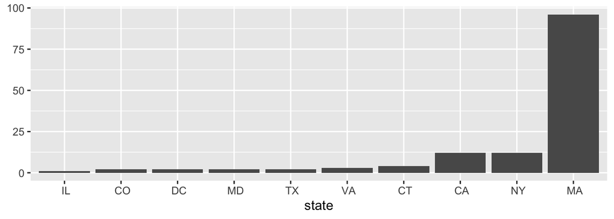

Even the searching result from the website take my location into account, from the list, we can see that the areas with most positions are Boston, Cambridge, New York, San Francisco. For areas out of MA, I think the reason they appear in the list is that they have really many job opportunities. If I consider the job in other areas, I could look for New York and San Francisco.

## List the companies with the most job positions of data scientists

| company | count |
| --- | --- |
| CVS Health | 5 |
| Biogen | 3 |
| Harvard University | 3 |
| Microsoft | 3 |
| InsideTracker | 2 |
| LanceSoft Inc | 2 |

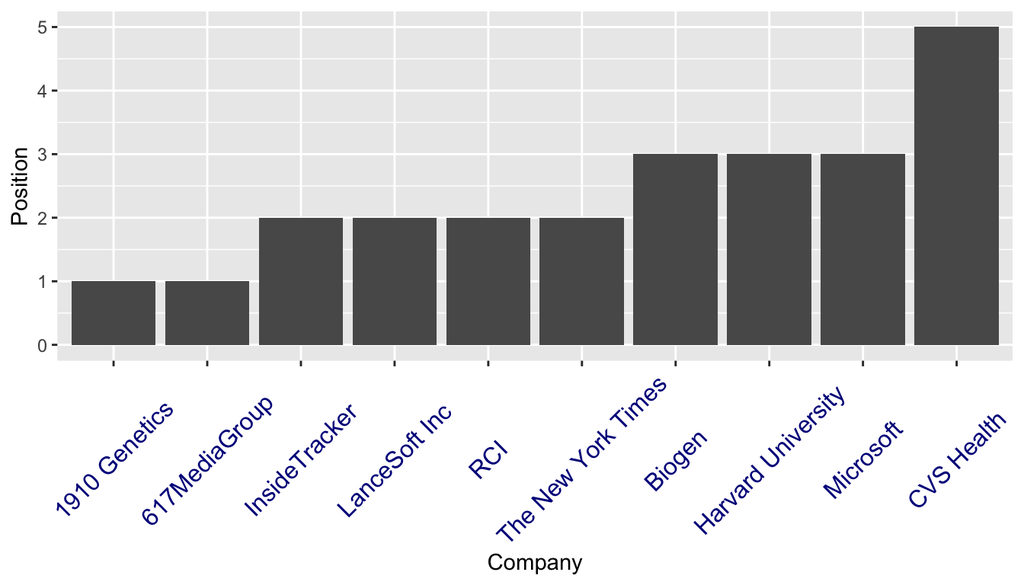

Within the nearby areas, CVS Health has 5 jobs related, ranking at 1st. Then Biogen, Harvard University, Microsoft has 3 job positions for data scientists or statisticians. 3 compaies out of the top 4 companies having most number of positions are related to biology, medical and health. So I get a conclusion that the companies in the biology field need data scientists the most.

# Description

Looking at the description of jobs, I want to know “what skills do the positions require”.

## Word Cloud

[interactive chart not shown]

## The most 10 common words in description

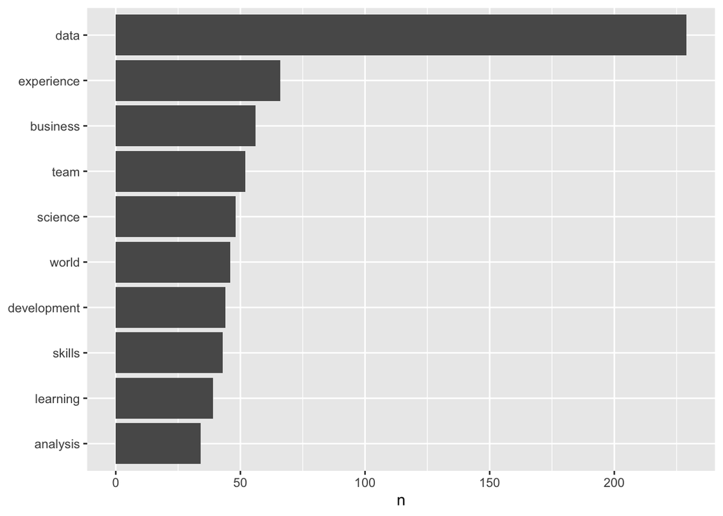

Besides “data”, word “experience” appear most. It might because that the job descriptions have the duty to mention whether they need people with or without experience, what kind of experience is preferred.

From the word cloud, I found that the words appear most frequently is “business, science, skills, development”. It surprised me that the word “business” appear larger than “science”. My interpretation is that the companies focus more on business value, talents’ ability to realize talent.

And I didn’t expect so many references to words " development" in the job descriptions. It might show that the employers are looking for long-term contribution of employees, who are expected to have the ability to learn. I think I need to prepare examples that show my self-learning ability.

The high frequency of the appearance of word “team” points to the requirement of teamwork in this job.

# Words appear together

Some words may come together. The following plot shows common bigrams of words, showing those that occurred more than 3 times and where neither word was a stop word

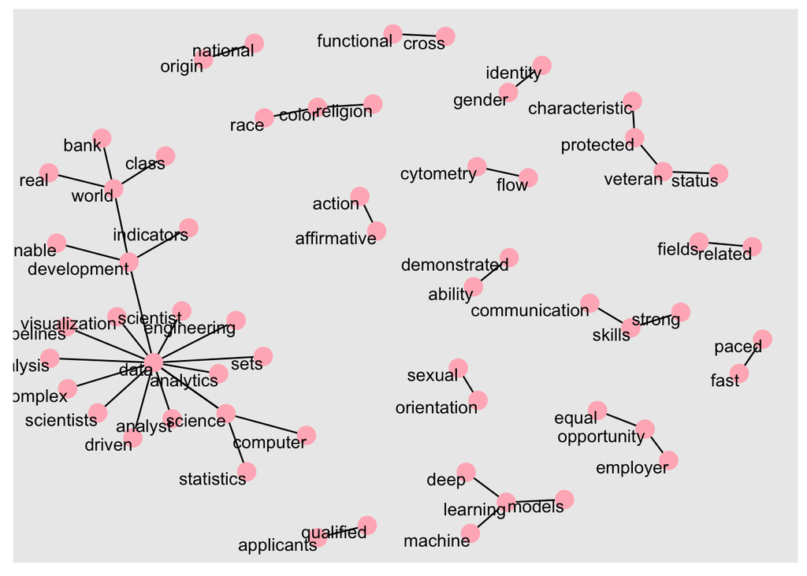

# The descriptions of jobs in two different areas

As my location is at Boston, I want to look at the job descriptions of the different areas nearby. The plot shows the comparison the word frequencies of Boston, Cambridge and Framingham.

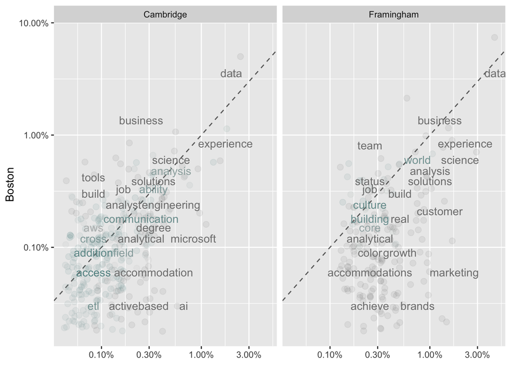

# Discussion

During the completion of this project, I expanded to discover many R functions, I learned from the examples in the book, the discussions that came up with searching, retrieving how the functions I wanted to implement and the problems I had to solve.

The text mining in this project helps me find some information that the job data scientists might be related to the area biology research, teamwork and business sense is also required. It tells me the number of positions of the areas or companies from the search result. I could also make comparisons between the descriptions of jobs in two different areas or different companies.

I intended to use code that could be used for other crawled data sets. For the time limit, I did not take any efforts in crawling data from other job websites, which could be done afterwards.